# 市场观察

2017/05/16

## A、指数估值

### (a1)动态市盈率、市净率

核心指数成分股近18个月的动态市盈率及动态市净率中位数走势如下图所示：

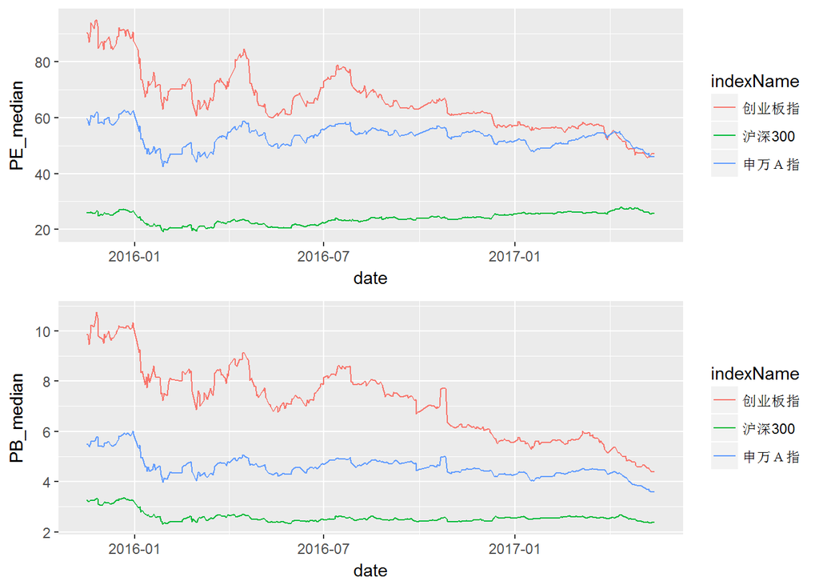

### (a2)动态市盈率、市净率百分位

核心指数近18个月的动态市盈率百分位及动态市净率百分位走势如下图所示：

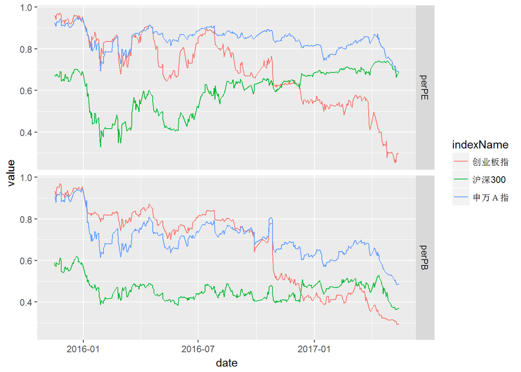

### (a3)指数估值概览

| 指数代码 | 指数简称 | 日期 | 动态市盈率 | 市盈率百分位 | 动态市净率 | 市净率百分位 |
| --- | --- | --- | --- | --- | --- | --- |
| EI801003 | 申万Ａ指 | 2017-05-15 | 46.1 | 69% | 3.6 | 49% |
| EI399330 | 深证100 | 2017-05-15 | 31.1 | 64% | 3.4 | 44% |
| EI000979 | 大宗商品 | 2017-05-15 | 31.3 | 57% | 2.6 | 49% |
| EI000300 | 沪深300 | 2017-05-15 | 26.0 | 69% | 2.4 | 37% |
| EI399959 | 军工指数 | 2017-05-15 | 81.2 | 54% | 4.0 | 49% |
| EI000819 | 有色金属 | 2017-05-15 | 50.5 | 66% | 2.9 | 22% |
| EI399005 | 中小板指P | 2017-05-15 | 38.5 | 54% | 4.1 | 31% |
| EI000016 | 上证50 | 2017-05-15 | 18.7 | 67% | 1.5 | 9% |
| EI000998 | 中证TMT | 2017-05-15 | 41.9 | 40% | 3.8 | 31% |
| EI000934 | 中证金融 | 2017-05-15 | 18.8 | 61% | 1.7 | 8% |
| EI000905 | 中证500 | 2017-05-15 | 34.3 | 42% | 2.7 | 26% |
| EI399006 | 创业板指 | 2017-05-15 | 47.2 | 30% | 4.4 | 30% |
| EI000827 | 中证环保 | 2017-05-15 | 36.2 | 33% | 2.6 | 12% |
| EI000922 | 中证红利 | 2017-05-15 | 15.0 | 17% | 1.6 | 12% |
| EI000932 | 中证消费 | 2017-05-15 | 27.8 | 14% | 3.4 | 5% |
| EI000933 | 中证医药 | 2017-05-15 | 31.0 | 13% | 3.5 | 1% |

### (a4)另类估值

我国10年期国债收益率、金银比价、金油比价，2000年以来的历史百分位如下图所示：

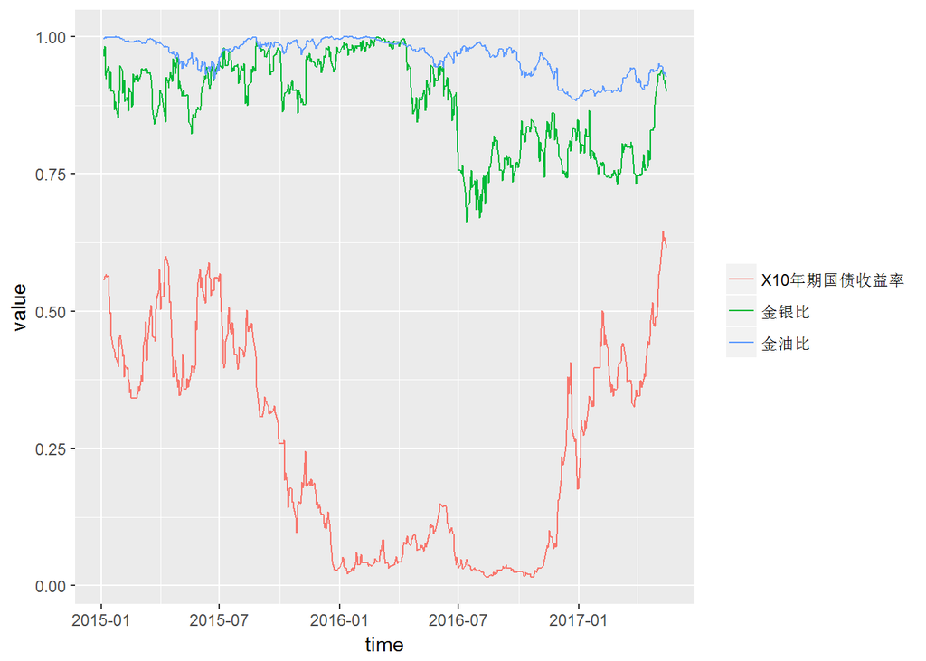

## B、基差及市场情绪

### (b1)基差走势

三大股指期货合约基差走势如下图，其中当月合约和次月合约年化基差百分比波动较大，仅展示合约基差百分比，当季合约和次季合约展示基差年化百分比：

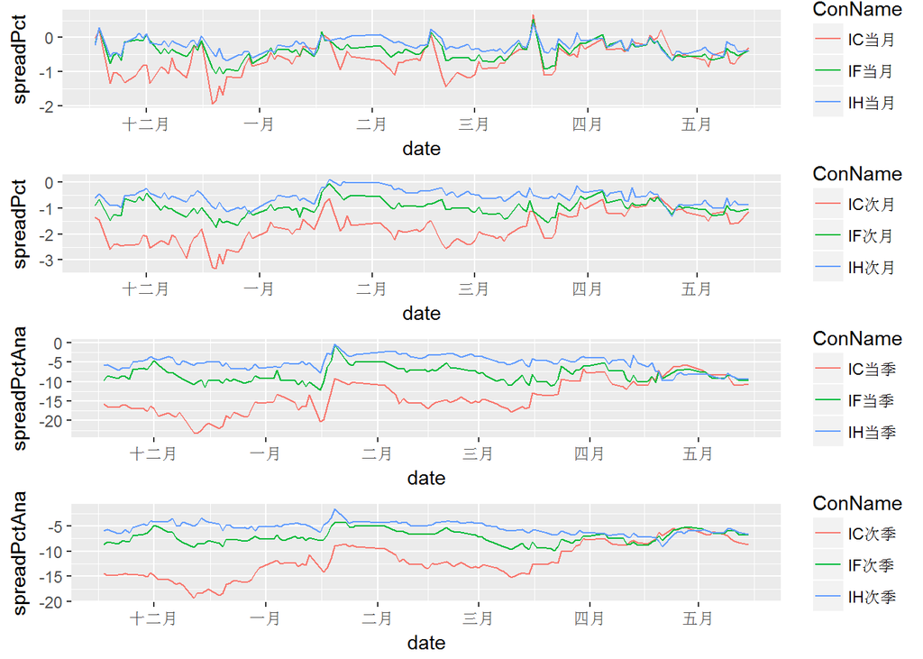

### (b2)基差概况

三大股指期货连续合约基差概况如下表，近月合约临近到期日，年化基差百分比数据波动较大：

| 日期 | 合约代码 | 合约收盘价 | 指数收盘价 | 基差 | 基差百分比 | 年化基差百分比 |
| --- | --- | --- | --- | --- | --- | --- |
| 2017-05-15 | IC1705 | 5876.8 | 5893.5 | -16.7 | -0.3% | -29.5% |
| 2017-05-15 | IC1706 | 5826.8 | 5893.5 | -66.7 | -1.1% | -13.7% |
| 2017-05-15 | IC1709 | 5690.0 | 5893.5 | -203.5 | -3.5% | -10.6% |
| 2017-05-15 | IC1712 | 5600.0 | 5893.5 | -293.5 | -5.0% | -8.6% |
| 2017-05-15 | IF1705 | 3386.6 | 3399.2 | -12.6 | -0.4% | -40.1% |
| 2017-05-15 | IF1706 | 3363.8 | 3399.2 | -35.4 | -1.0% | -12.5% |
| 2017-05-15 | IF1709 | 3291.2 | 3399.2 | -108.0 | -3.2% | -9.7% |
| 2017-05-15 | IF1712 | 3267.2 | 3399.2 | -132.0 | -3.9% | -6.7% |
| 2017-05-15 | IH1705 | 2372.8 | 2381.8 | -9.0 | -0.4% | -40.8% |
| 2017-05-15 | IH1706 | 2360.6 | 2381.8 | -21.2 | -0.9% | -10.6% |
| 2017-05-15 | IH1709 | 2308.8 | 2381.8 | -73.0 | -3.1% | -9.4% |
| 2017-05-15 | IH1712 | 2290.8 | 2381.8 | -91.0 | -3.8% | -6.6% |

### (b3)市场情绪(provided by han.qian)

市场情绪记录今年以来每天自然涨跌停(剔除一字板)、创60日新高新低、多头排列空头排列(均线组合5,30,60,120)的股票数。

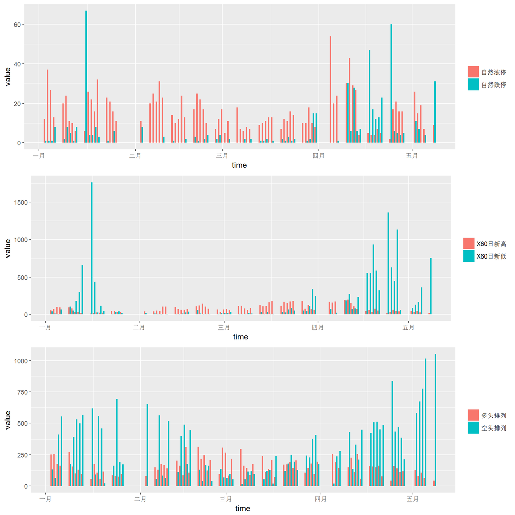

## C、套利和事件

### (c1)复牌股票套利

近两天复牌股票套利情况如下表：

[1] “No Arbitrage!”

### (c2)定增基金(provided by han.qian)

定增基金数据如下表，明细数据参见钱瀚的模板。

| 代码 | 名称 | 到期日期 | 最新净值 | 昨日收盘价 | 折溢价率 | 整体隐含折价率 | 大盘下跌0.1净值变化 |
| --- | --- | --- | --- | --- | --- | --- | --- |
| 168101.OF | 九泰锐智 | 20200814 | 1.13 | 0.98 | -13.8% | 2.9% | -10.0% |
| 168102.OF | 九泰锐富 | 20210204 | 0.99 | 0.81 | -18.3% | 2.5% | -5.6% |
| 501015.OF | 财通升级 | 20170908 | 0.96 | 0.91 | -4.8% | 1.1% | -9.1% |
| 160518.OF | 博时睿远 | 20171016 | 0.93 | 0.89 | -4.6% | 0.8% | -6.7% |

定增基金近期的净值走势如下图：

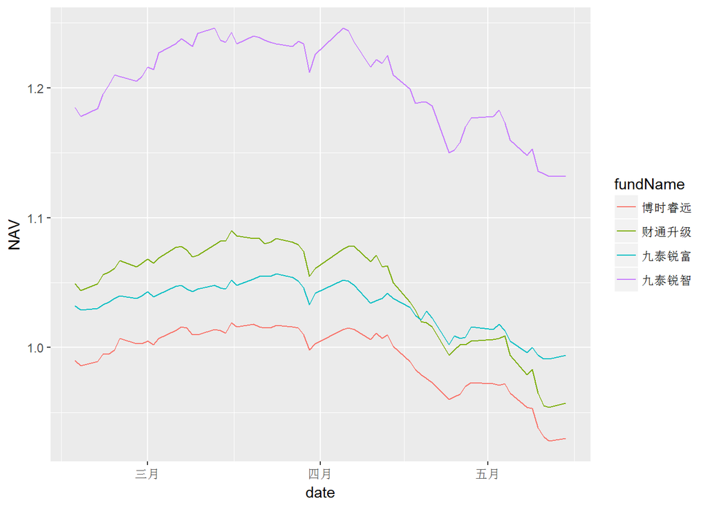

定增基金近期的折溢价率百分比走势如下图：

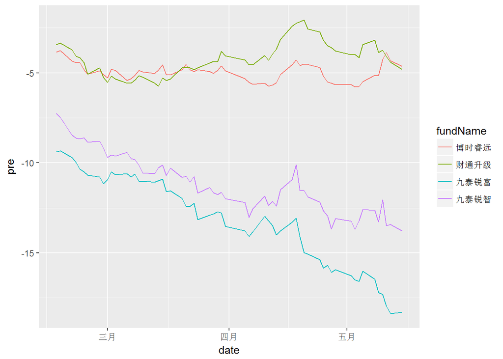

### (c3)解禁

解禁分成两个部分，定增解禁和IPO解禁，涨跌幅记录是过去十个交易日的股票涨跌幅和对应行业指数涨跌幅。伴随着去年下半年IPO逐步正常化，今后IPO解禁给市场造成的抛压会持续存在，所以纳入观察。近期定增解禁的股票情况如下表。

|  | 股票代码 | 股票简称 | 解禁日 | 解禁数量 | 解禁百分比 | 区间涨跌幅 | 所属行业指数 | 行业指数涨跌幅 |
| --- | --- | --- | --- | --- | --- | --- | --- | --- |
| 40 | EQ300059 | 东方财富 | 2017-05-17 | 2.46 | 8% | -3.5% | 申万传媒 | -3.4% |
| 41 | EQ002619 | 巨龙管业 | 2017-05-17 | 0.39 | 13% | -3.4% | 申万传媒 | -3.4% |
| 42 | EQ002174 | 游族网络 | 2017-05-17 | 2.68 | 87% | -13.2% | 申万传媒 | -3.4% |
| 44 | EQ002517 | 恺英网络 | 2017-05-17 | 0.22 | 10% | -0.9% | 申万传媒 | -3.4% |
| 45 | EQ300166 | 东方国信 | 2017-05-17 | 0.78 | 19% | -3.8% | 申万计算机 | -3.0% |
| 46 | EQ000420 | 吉林化纤 | 2017-05-17 | 3.50 | 55% | -12.2% | 申万化工 | -4.7% |
| 47 | EQ300157 | 恒泰艾普 | 2017-05-17 | 0.31 | 5% | 4.9% | 申万采掘 | -4.9% |
| 48 | EQ002425 | 凯撒文化 | 2017-05-18 | 0.50 | 24% | -8.3% | 申万纺织服装 | -3.9% |
| 51 | EQ002670 | 国盛金控 | 2017-05-19 | 2.69 | 121% | -9.9% | 申万家用电器 | -0.1% |
| 52 | EQ300410 | 正业科技 | 2017-05-19 | 0.18 | 34% | -4.0% | 申万电子 | -1.6% |
| 54 | EQ600770 | 综艺股份 | 2017-05-19 | 1.95 | 18% | -8.7% | 申万综合 | -6.5% |
| 55 | EQ300301 | 长方集团 | 2017-05-22 | 1.00 | 25% | -3.2% | 申万电子 | -1.6% |
| 56 | EQ300195 | 长荣股份 | 2017-05-22 | 0.36 | 23% | -4.8% | 申万机械设备 | -5.0% |
| 57 | EQ600090 | 同济堂 | 2017-05-22 | 3.35 | 91% | -12.0% | 申万食品饮料 | -1.7% |
| 58 | EQ002708 | 光洋股份 | 2017-05-23 | 0.15 | 7% | -8.4% | 申万汽车 | -5.0% |
| 59 | EQ002558 | 世纪游轮 | 2017-05-25 | 1.60 | 122% | -20.3% | 申万休闲服务 | -4.6% |
| 61 | EQ600811 | 东方集团 | 2017-05-25 | 8.51 | 51% | -6.5% | 申万综合 | -6.5% |
| 62 | EQ002671 | 龙泉股份 | 2017-05-26 | 0.17 | 5% | 3.6% | 申万建筑材料 | -5.2% |
| 63 | EQ002077 | 大港股份 | 2017-05-26 | 0.46 | 18% | -3.9% | 申万房地产 | -4.7% |
| 66 | EQ600538 | 国发股份 | 2017-05-31 | 1.85 | 66% | -18.9% | 申万化工 | -4.7% |
| 68 | EQ000035 | 中国天楹 | 2017-05-31 | 4.27 | 53% | -5.7% | 申万公用事业 | -4.3% |
| 69 | EQ300279 | 和晶科技 | 2017-05-31 | 0.11 | 11% | -1.9% | 申万电子 | -1.6% |
| 70 | EQ600157 | 永泰能源 | 2017-05-31 | 12.31 | 27% | -2.2% | 申万采掘 | -4.9% |
| 72 | EQ002745 | 木林森 | 2017-05-31 | 0.84 | 107% | -0.3% | 申万电子 | -1.6% |
| 74 | EQ300190 | 维尔利 | 2017-05-31 | 0.60 | 18% | -6.8% | 申万公用事业 | -4.3% |

近期IPO解禁的股票情况如下表。

|  | 股票代码 | 股票简称 | 解禁日 | 解禁数量 | 解禁百分比 | 区间涨跌幅 | 所属行业指数 | 行业指数涨跌幅 | 上市日 |
| --- | --- | --- | --- | --- | --- | --- | --- | --- | --- |
| 1 | EQ300434 | 金石东方 | 2017-05-02 | 0.22 | 64% | -6.8% | 申万机械设备 | -5.0% | 2015-04-24 |
| 2 | EQ603528 | 多伦科技 | 2017-05-03 | 0.11 | 21% | -16.7% | 申万汽车 | -5.0% | 2016-05-03 |
| 5 | EQ300511 | 雪榕生物 | 2017-05-04 | 0.26 | 69% | -13.6% | 申万农林牧渔 | -6.8% | 2016-05-04 |
| 11 | EQ603101 | 汇嘉时代 | 2017-05-08 | 0.12 | 20% | -9.2% | 申万商业贸易 | -4.6% | 2016-05-06 |
| 13 | EQ300510 | 金冠电气 | 2017-05-08 | 0.46 | 105% | 0.0% | 申万电气设备 | -6.5% | 2016-05-06 |
| 19 | EQ300451 | 创业软件 | 2017-05-09 | 0.09 | 7% | -3.5% | 申万计算机 | -3.0% | 2015-05-14 |
| 26 | EQ002796 | 世嘉科技 | 2017-05-10 | 0.10 | 50% | -4.5% | 申万机械设备 | -5.0% | 2016-05-10 |
| 27 | EQ002797 | 第一创业 | 2017-05-11 | 9.80 | 448% | -41.0% | 申万非银金融 | -0.4% | 2016-05-11 |
| 31 | EQ300414 | 中光防雷 | 2017-05-15 | 0.18 | 28% | 0.0% | 申万电气设备 | -6.5% | 2015-05-13 |
| 33 | EQ300455 | 康拓红外 | 2017-05-15 | 0.10 | 12% | -8.6% | 申万计算机 | -3.0% | 2015-05-15 |
| 37 | EQ603779 | 威龙股份 | 2017-05-16 | 0.42 | 84% | -16.2% | 申万食品饮料 | -1.7% | 2016-05-16 |
| 43 | EQ603959 | 百利科技 | 2017-05-17 | 0.50 | 90% | -21.1% | 申万建筑装饰 | -4.9% | 2016-05-17 |
| 53 | EQ603339 | 四方冷链 | 2017-05-19 | 0.05 | 10% | -17.2% | 申万机械设备 | -5.0% | 2016-05-19 |
| 60 | EQ002798 | 帝王洁具 | 2017-05-25 | 0.11 | 49% | -11.7% | 申万轻工制造 | -4.8% | 2016-05-25 |
| 64 | EQ300512 | 中亚股份 | 2017-05-26 | 0.11 | 16% | -12.7% | 申万机械设备 | -5.0% | 2016-05-26 |
| 65 | EQ603885 | 吉祥航空 | 2017-05-31 | 0.21 | 6% | -7.2% | 申万交通运输 | -2.8% | 2015-05-27 |
| 67 | EQ300513 | 恒泰实达 | 2017-05-31 | 0.26 | 138% | -12.9% | 申万计算机 | -3.0% | 2016-05-30 |
| 71 | EQ002800 | 天顺股份 | 2017-05-31 | 0.19 | 103% | -6.5% | 申万交通运输 | -2.8% | 2016-05-30 |
| 75 | EQ601198 | 东兴证券 | 2017-05-31 | 1.00 | 11% | 0.2% | 申万非银金融 | -0.4% | 2015-02-26 |

### (c4)中小板业绩预增预测(provided by han.qian)

中小板规定正式财务报告发布的同时需要发布新一期的业绩预报，比如年报中会包含一季报预告的情况。我们假设公司的盈利状况有动量效应，年报预增的公司一季度也会预增，在正式财务报告发布前20个交易日开始埋伏，然后等正式报告发布日卖出。具体研究参见钱瀚前期的研究。需要注意的是这里的收益率仅做展示，仅仅是每日全部入选股票的平均收益率，并没有做成一个事件组合。

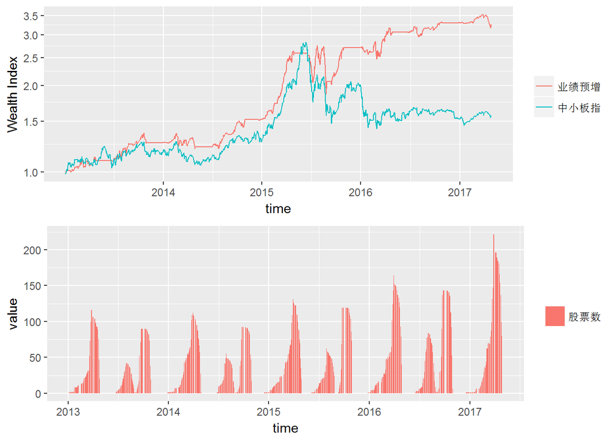

历年收益统计如下表所示。

|  | 业绩预增 | 中小板指 |
| --- | --- | --- |
| 2013-01-04 ~ 2013-12-31 | 26.4% | 17.5% |
| 2014-01-02 ~ 2014-12-31 | 20.7% | 9.7% |
| 2015-01-05 ~ 2015-12-31 | 77.7% | 53.7% |
| 2016-01-04 ~ 2016-12-30 | 22.3% | -22.9% |
| 2017-01-03 ~ 2017-04-28 | -1.2% | 2.6% |
| Cumulative Return | 227.7% | 56.7% |
| Annualized Return | 31.6% | 11.0% |

### (c5)ST摘帽(provided by han.qian)

具体策略可以参见吴先兴的潜伏ST摘帽报告。

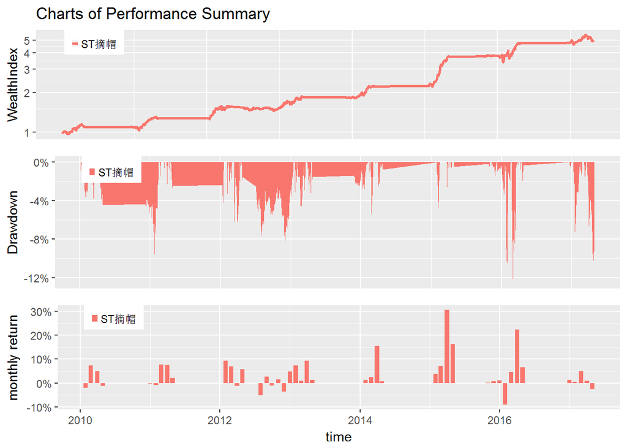

最新持仓如下表所示。

| date | stockID | stockName | wgt |
| --- | --- | --- | --- |
| 2017-04-28 | EQ000505 | *ST 珠江 | 0.1 |
| 2017-04-28 | EQ000511 | *ST 烯碳 | 0.1 |
| 2017-04-28 | EQ600339 | 中油工程 | 0.1 |

### (c6)主动量化基金

主动量化基金最近一年和最近一个季度的收益率密度图如下所示。

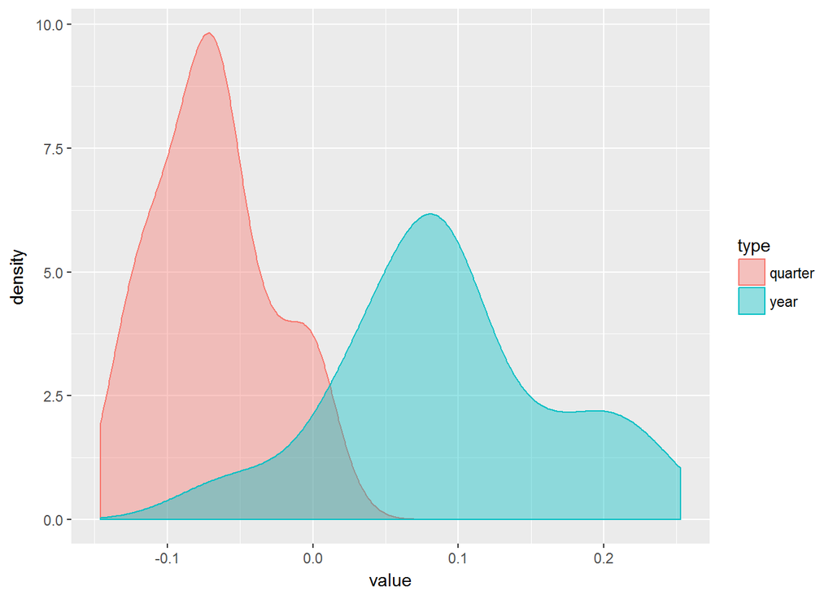

主动量化基金近一年和近一个季度表现最好的20只基金如下表所示。

| 季度排名 | 基金简称 | 成立日 | 总规模 | 季度收益 | 年度排名 | 基金简称 | 成立日 | 总规模 | 年度收益 |
| --- | --- | --- | --- | --- | --- | --- | --- | --- | --- |
| 1 | 金信量化精选 | 2016-07-01 | 2.1 | 2.5% | 1 | 华泰柏瑞量化优选 | 2014-12-17 | 7.2 | 25.3% |
| 2 | 景顺长城量化新动力 | 2016-07-13 | 1.2 | 0.9% | 2 | 华泰柏瑞量化智慧 | 2015-06-03 | 5.3 | 23.0% |
| 3 | 华泰柏瑞量化优选 | 2014-12-17 | 7.2 | 0.5% | 3 | 华泰柏瑞量化先行 | 2010-06-22 | 5.6 | 21.7% |
| 4 | 东吴安鑫量化 | 2016-06-03 | 2.4 | 0.3% | 4 | 华泰柏瑞量化驱动 | 2015-03-24 | 19.5 | 21.1% |
| 5 | 华润元大医疗保健量化 | 2014-08-18 | 0.5 | 0.1% | 5 | 泰达宏利同顺大数据A | 2016-02-23 | 2.1 | 20.5% |
| 6 | 华泰柏瑞量化驱动 | 2015-03-24 | 19.5 | -0.1% | 6 | 华泰柏瑞量化A | 2013-08-02 | 46.7 | 19.8% |
| 7 | 华泰柏瑞量化智慧 | 2015-06-03 | 5.3 | -0.3% | 7 | 九泰久盛量化先锋A | 2015-11-10 | 4.5 | 18.7% |
| 8 | 华泰柏瑞量化A | 2013-08-02 | 46.7 | -0.5% | 8 | 泰达宏利逆向策略 | 2012-05-23 | 16.2 | 16.2% |
| 9 | 长盛量化红利策略 | 2009-11-25 | 2.5 | -0.7% | 9 | 泰达宏利改革动力A | 2015-02-13 | 18.4 | 15.7% |
| 10 | 华泰柏瑞量化先行 | 2010-06-22 | 5.6 | -0.7% | 10 | 景顺长城量化精选 | 2015-02-04 | 13.4 | 15.1% |
| 11 | 长盛医疗行业 | 2016-02-03 | 0.6 | -2.3% | 11 | 华富量子生命力 | 2011-04-01 | 0.8 | 13.5% |
| 12 | 华商量化进取 | 2015-04-09 | 26.7 | -2.5% | 12 | 申万菱信量化小盘 | 2011-06-16 | 30.9 | 11.0% |
| 13 | 平安大华量化A | 2017-01-23 | 2.0 | -2.9% | 13 | 华商大盘量化精选 | 2013-04-09 | 12.3 | 10.6% |
| 14 | 泰达宏利量化 | 2016-08-30 | 1.9 | -2.9% | 14 | 大成核心双动力 | 2010-06-22 | 1.3 | 10.4% |
| 15 | 平安大华量化C | 2017-01-23 | 0.0 | -3.1% | 15 | 长盛量化红利策略 | 2009-11-25 | 2.5 | 10.0% |
| 16 | 民生加银量化中国 | 2016-05-19 | 1.4 | -3.1% | 16 | 长信量化多策略 | 2015-07-14 | 3.3 | 10.0% |
| 17 | 建信多因子量化 | 2016-08-09 | 1.9 | -4.1% | 17 | 华润元大医疗保健量化 | 2014-08-18 | 0.5 | 9.8% |
| 18 | 华商新量化 | 2014-06-05 | 6.3 | -4.4% | 18 | 南方策略优化 | 2010-03-30 | 13.8 | 9.5% |
| 19 | 泰达宏利改革动力C | 2017-02-09 | 0.0 | -4.9% | 19 | 长信量化先锋A | 2010-11-18 | 85.9 | 9.2% |
| 20 | 泰达宏利改革动力A | 2015-02-13 | 18.4 | -5.0% | 20 | 南方量化成长 | 2015-06-29 | 14.2 | 9.0% |

## D、择时

### (d1)等权指数

从历史来看，A股市场存在小盘股效应，市值小的股票长期整体跑赢大市值的股票，美股市场同样存在类似的现象。而目前大部分指数的编制方案都是类似市值加权，为了抛去市值的影响，下面展示几个等权指数，其中中证500等权和沪深300等权是现有的指数，中证全指等权是自己编制的指数。等权指数可以视为一个更好地业绩比较基准。等权指数走势如下图：

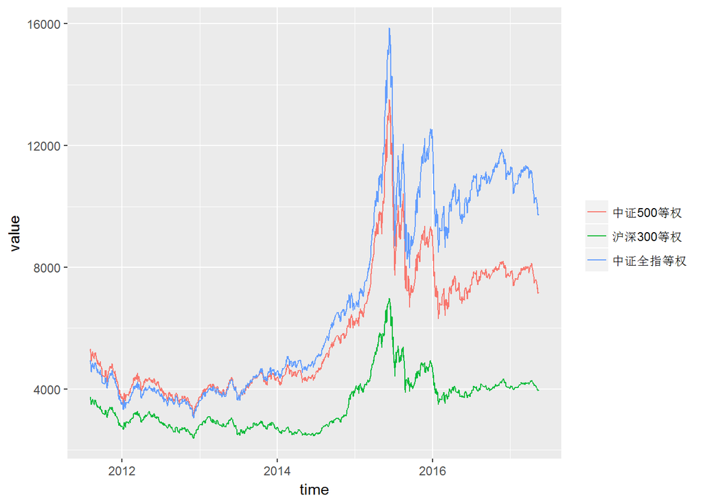

等权指数收益率统计见下表：

|  | 中证500等权 | 沪深300等权 | 中证全指等权 |
| --- | --- | --- | --- |
| 2011-08-02 ~ 2011-12-30 | -29.2% | -25.5% | -27.8% |
| 2012-01-04 ~ 2012-12-31 | -0.0% | 1.5% | 2.2% |
| 2013-01-04 ~ 2013-12-31 | 16.7% | -3.2% | 25.8% |
| 2014-01-02 ~ 2014-12-31 | 40.2% | 43.7% | 46.0% |
| 2015-01-05 ~ 2015-12-31 | 47.6% | 20.1% | 84.4% |
| 2016-01-04 ~ 2016-12-30 | -15.1% | -15.1% | -10.3% |
| 2017-01-03 ~ 2017-05-15 | -6.8% | -1.3% | -11.8% |
| 累计收益率 | 35.4% | 6.0% | 97.8% |
| 年化收益率 | 5.4% | 1.0% | 12.5% |
| 年化波动率 | 28.5% | 25.8% | 28.9% |
| 年化Sharpe值 | 18.8% | 3.9% | 43.2% |
| 最大回撤 | 53.3% | 50.0% | 49.7% |

### (d2)大盘均线强弱指数

大盘均线强弱指数在一定程度上可以视为一个反转指标，当大盘均线得分接近8分时，预示市场接近顶部，当大盘均线得分接近0分时，预示市场接近底部。  
大盘均线强弱指数近一年来走势如下图：

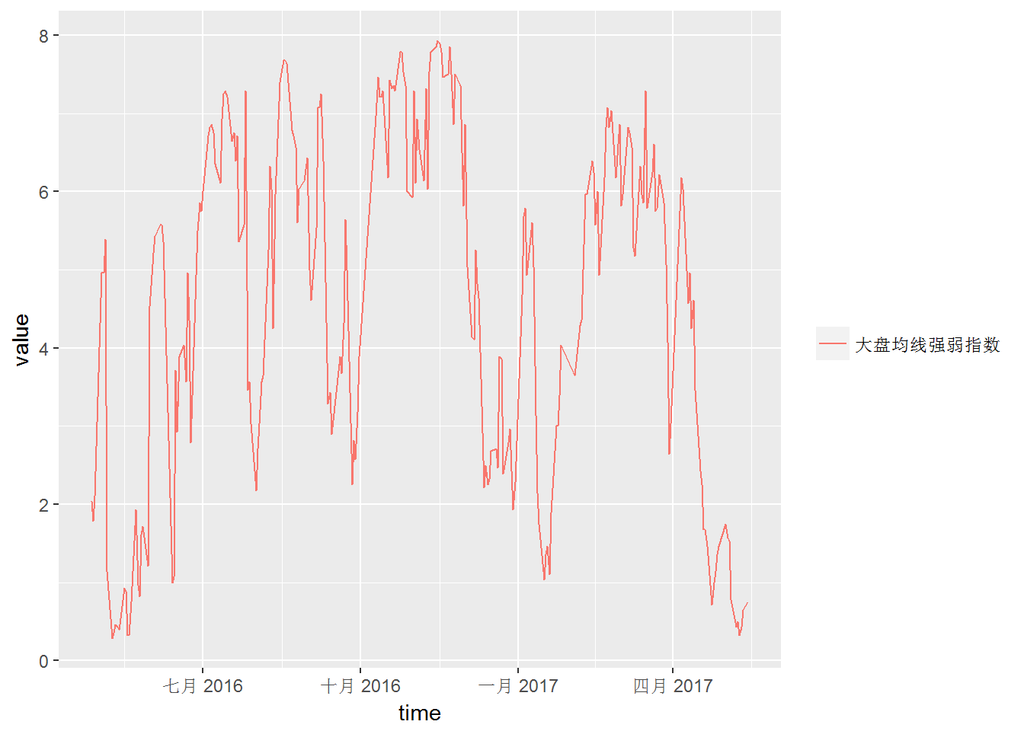

申万一级行业的最新得分见下表：

| 日期 | 指数代码 | 行业 | 最新得分 | 上周得分 |
| --- | --- | --- | --- | --- |
| 2017-05-15 | EI801110 | 家用电器 | 5 | 3 |
| 2017-05-15 | EI801780 | 银行 | 5 | 0 |
| 2017-05-15 | EI801120 | 食品饮料 | 4 | 3 |
| 2017-05-15 | EI801790 | 非银金融 | 4 | 0 |
| 2017-05-15 | EI801080 | 电子 | 1 | 0 |
| 2017-05-15 | EI801710 | 建筑材料 | 1 | 2 |
| 2017-05-15 | EI801720 | 建筑装饰 | 1 | 2 |
| 2017-05-15 | EI801010 | 农林牧渔 | 0 | 0 |
| 2017-05-15 | EI801020 | 采掘 | 0 | 0 |
| 2017-05-15 | EI801030 | 化工 | 0 | 0 |
| 2017-05-15 | EI801040 | 钢铁 | 0 | 1 |
| 2017-05-15 | EI801050 | 有色金属 | 0 | 0 |
| 2017-05-15 | EI801130 | 纺织服装 | 0 | 0 |
| 2017-05-15 | EI801140 | 轻工制造 | 0 | 0 |
| 2017-05-15 | EI801150 | 医药生物 | 0 | 0 |
| 2017-05-15 | EI801160 | 公用事业 | 0 | 1 |
| 2017-05-15 | EI801170 | 交通运输 | 0 | 1 |
| 2017-05-15 | EI801180 | 房地产 | 0 | 0 |
| 2017-05-15 | EI801200 | 商业贸易 | 0 | 0 |
| 2017-05-15 | EI801210 | 休闲服务 | 0 | 0 |
| 2017-05-15 | EI801230 | 综合 | 0 | 0 |
| 2017-05-15 | EI801730 | 电气设备 | 0 | 0 |
| 2017-05-15 | EI801740 | 国防军工 | 0 | 0 |
| 2017-05-15 | EI801750 | 计算机 | 0 | 0 |
| 2017-05-15 | EI801760 | 传媒 | 0 | 1 |
| 2017-05-15 | EI801770 | 通信 | 0 | 0 |
| 2017-05-15 | EI801880 | 汽车 | 0 | 0 |
| 2017-05-15 | EI801890 | 机械设备 | 0 | 0 |

### (d3)LLT及均线择时

LLT本质上是一个改进的单均线择时指标，较原始的均线择时延迟更低。  
择时模型和指数本身的净值走势如下图：

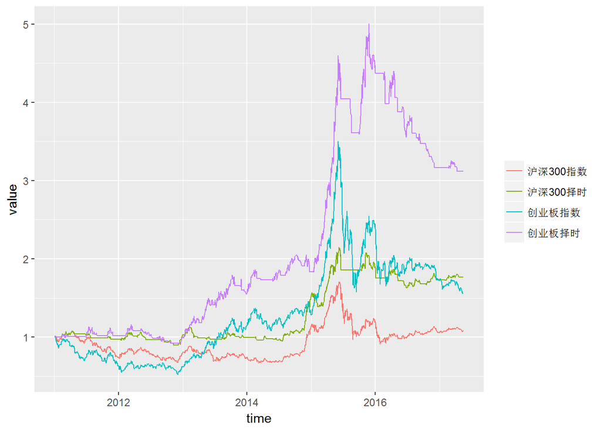

择时模型和指数的收益率统计如下表：

|  | 沪深300指 | 沪深300LLT | 创业板指 | 创业板MA |
| --- | --- | --- | --- | --- |
| 2011-01-04 ~ 2011-12-30 | -25.0% | -2.5% | -35.9% | 1.9% |
| 2012-01-04 ~ 2012-12-31 | 7.6% | 5.4% | -2.1% | -1.7% |
| 2013-01-04 ~ 2013-12-31 | -7.6% | -3.2% | 82.7% | 55.7% |
| 2014-01-02 ~ 2014-12-31 | 51.7% | 52.4% | 12.8% | 17.7% |
| 2015-01-05 ~ 2015-12-31 | 5.6% | 24.3% | 84.4% | 138.1% |
| 2016-01-04 ~ 2016-12-30 | -11.3% | -8.1% | -27.7% | -27.5% |
| 2017-01-03 ~ 2017-05-15 | 2.7% | 1.9% | -9.3% | -1.6% |
| 累计收益率 | 8.7% | 76.7% | 56.3% | 211.7% |
| 年化收益率 | 1.3% | 9.4% | 7.3% | 19.5% |
| 年化波动率 | 23.9% | 15.3% | 32.6% | 21.9% |
| 年化Sharpe值 | 5.5% | 61.0% | 22.3% | 89.3% |
| 最大回撤 | 46.7% | 24.0% | 55.5% | 37.7% |

择时模型最近10个交易日的信号如下表：

| 日期 | 沪深300收盘价 | 沪深300LLT | 沪深300择时信号 | 创业板收盘价 | 创业板MA30 | 创业板择时信号 |
| --- | --- | --- | --- | --- | --- | --- |
| 2017-05-02 | 3426.577 | 3480.182 |  | 1850.849 | 1898.425 |  |
| 2017-05-03 | 3413.128 | 3477.312 |  | 1840.453 | 1894.785 |  |
| 2017-05-04 | 3404.386 | 3473.844 |  | 1838.104 | 1890.928 |  |
| 2017-05-05 | 3382.550 | 3469.535 |  | 1818.191 | 1886.165 |  |
| 2017-05-08 | 3358.812 | 3463.940 |  | 1788.708 | 1880.836 |  |
| 2017-05-09 | 3352.532 | 3457.630 |  | 1802.491 | 1875.974 |  |
| 2017-05-10 | 3337.701 | 3450.931 |  | 1771.320 | 1869.513 |  |
| 2017-05-11 | 3356.646 | 3444.684 |  | 1772.413 | 1863.676 |  |
| 2017-05-12 | 3385.379 | 3440.285 |  | 1774.628 | 1858.018 |  |
| 2017-05-15 | 3399.194 | 3437.480 |  | 1778.636 | 1852.999 |  |

### (d4)网格交易

在经历了三轮股灾，A股逐步回归正常，在过去的一段时间呈现一个震荡的格局，如果未来没有增量信息，很可能维持震荡。结合股指期货的贴水，前期研究了一下网格交易。网格交易的结果如下图：

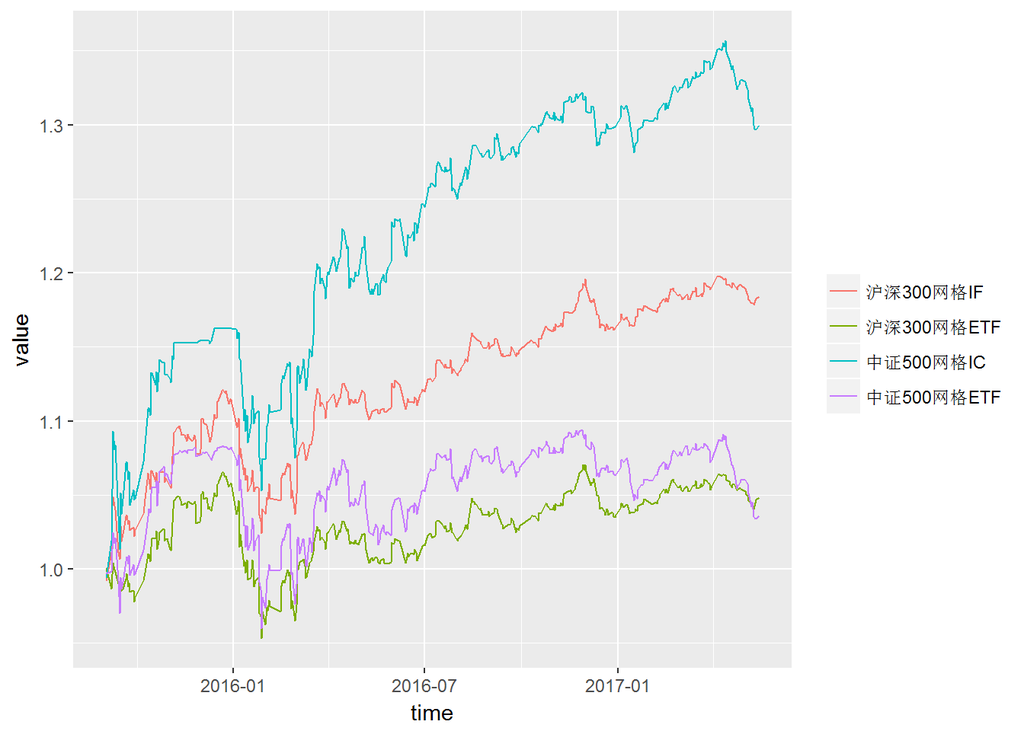

网格交易的收益统计如下表：

|  | 沪深300指数 | 沪深300网格IF | 沪深300网格ETF | 中证500指数 | 中证500网格IC | 中证500网格ETF |
| --- | --- | --- | --- | --- | --- | --- |
| 2015-09-02 ~ 2015-12-31 | 11.0% | 11.1% | 5.6% | 23.5% | 16.2% | 8.1% |
| 2016-01-04 ~ 2016-12-30 | -11.3% | 4.7% | -1.8% | -17.8% | 11.8% | -1.6% |
| 2017-01-03 ~ 2017-05-15 | 2.7% | 1.8% | 1.1% | -5.9% | 0.0% | -2.6% |
| 累计收益率 | 1.1% | 18.4% | 4.9% | -4.5% | 30.0% | 3.6% |
| 年化收益率 | 0.6% | 10.4% | 2.8% | -2.6% | 16.6% | 2.1% |
| 年化波动率 | 21.2% | 8.8% | 8.6% | 28.6% | 13.1% | 11.2% |
| 年化Sharpe值 | 3.0% | 117.7% | 32.7% | -9.2% | 127.1% | 18.9% |
| 最大回撤 | 26.4% | 8.6% | 10.5% | 33.5% | 9.4% | 11.4% |

## E、选股

### (e1)大小市值100

作为多因子选股的第一部分，有必要从市值因子说起。 下面利用总市值因子，在中证全指的成分股内，选出市值最大和最小的100只股票，这里剔除了ST、新上市、停牌和涨停的股票，等权配置，每月换仓一次，交易成本千分之三。观察历年来大、小市值组净值表现如下图。

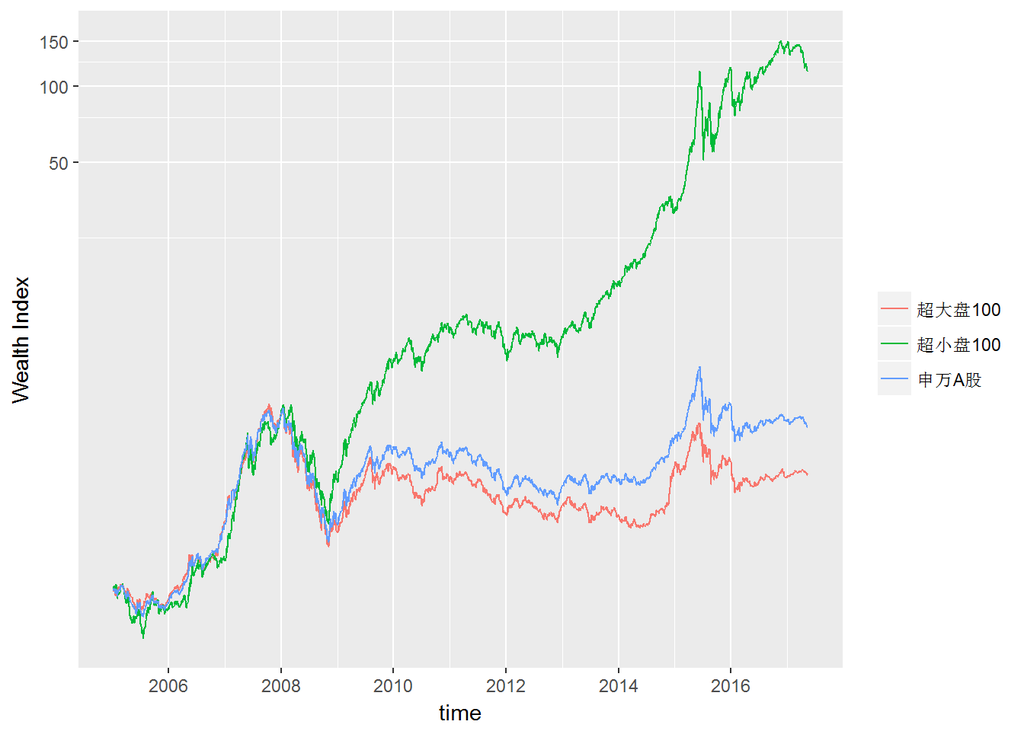

大小市值100的收益统计如下表：

|  | 超大盘100 | 超小盘100 | 申万A股 |
| --- | --- | --- | --- |
| 2005-01-05 ~ 2005-12-30 | -8.0% | -15.5% | -10.1% |
| 2006-01-04 ~ 2006-12-29 | 104.5% | 56.5% | 103.9% |
| 2007-01-04 ~ 2007-12-28 | 163.5% | 270.9% | 167.2% |
| 2008-01-02 ~ 2008-12-31 | -65.6% | -45.1% | -62.8% |
| 2009-01-05 ~ 2009-12-31 | 82.8% | 206.5% | 105.6% |
| 2010-01-04 ~ 2010-12-31 | -9.9% | 32.0% | -6.8% |
| 2011-01-04 ~ 2011-12-30 | -27.2% | -19.5% | -28.6% |
| 2012-01-04 ~ 2012-12-31 | 7.7% | 15.8% | 4.9% |
| 2013-01-04 ~ 2013-12-31 | -9.2% | 65.4% | 6.3% |
| 2014-01-02 ~ 2014-12-31 | 55.5% | 89.8% | 44.9% |
| 2015-01-05 ~ 2015-12-31 | 4.5% | 266.7% | 35.3% |
| 2016-01-04 ~ 2016-12-30 | -13.5% | 24.7% | -13.6% |
| 2017-01-03 ~ 2017-05-15 | 3.9% | -20.9% | -4.7% |
| 累计收益率 | 192.4% | 11435.2% | 348.6% |
| 年化收益率 | 9.1% | 46.8% | 12.9% |
| 年化波动率 | 29.0% | 35.7% | 28.5% |
| 年化Sharpe值 | 31.2% | 131.2% | 45.2% |
| 最大回撤 | 72.9% | 66.4% | 70.5% |

### (e2)银行股轮动

银行股轮动是参考集思录的热门贴银行股评级而来的，数据的提取和参数的设置和原贴有一定的差别，所以轮动的效果也会不太一样，不过回测的效果还不错，从现在开始跟踪。2013年以来银行股轮动的结果如下图：

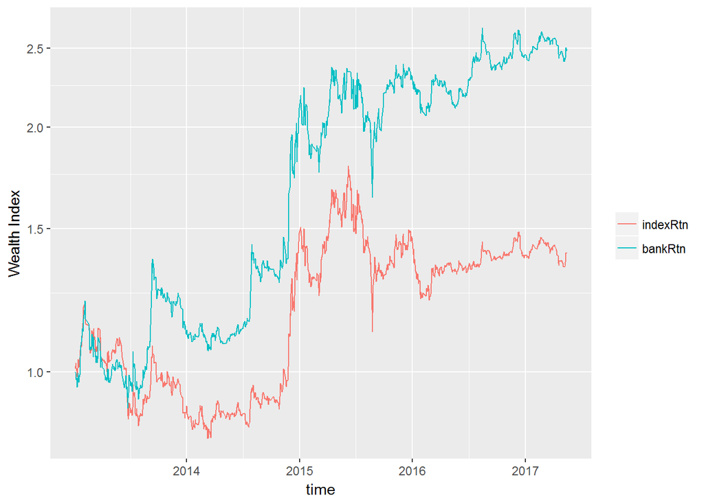

银行股轮动的收益统计如下表：

|  | 申万银行 | 银行股轮动 |
| --- | --- | --- |
| 2013-01-04 ~ 2013-12-31 | -9.2% | 12.5% |
| 2014-01-02 ~ 2014-12-31 | 63.2% | 87.6% |
| 2015-01-05 ~ 2015-12-31 | -1.4% | 9.4% |
| 2016-01-04 ~ 2016-12-30 | -4.9% | 6.2% |
| 2017-01-04 ~ 2017-05-15 | 0.7% | 1.2% |
| 累计收益率 | 39.9% | 148.2% |
| 年化收益率 | 8.0% | 23.2% |
| 年化波动率 | 27.9% | 29.8% |
| 年化Sharpe值 | 28.7% | 77.6% |
| 最大回撤 | 37.4% | 30.8% |

银行股轮动的最新得分如下表：

| 日期 | 代码 | 简称 | PB | ROE | 翻倍期 | 持仓 |
| --- | --- | --- | --- | --- | --- | --- |
| 2017-05-15 | EQ600015 | 华夏银行 | 0.73 | 0.13 | 3.2 | hold |
| 2017-05-15 | EQ601818 | 光大银行 | 0.74 | 0.12 | 3.6 |  |
| 2017-05-15 | EQ601328 | 交通银行 | 0.71 | 0.10 | 3.6 |  |
| 2017-05-15 | EQ000001 | 平安银行 | 0.75 | 0.11 | 3.9 |  |
| 2017-05-15 | EQ601988 | 中国银行 | 0.76 | 0.11 | 3.9 |  |
| 2017-05-15 | EQ601288 | 农业银行 | 0.85 | 0.14 | 4.1 |  |
| 2017-05-15 | EQ600016 | 民生银行 | 0.85 | 0.14 | 4.1 |  |
| 2017-05-15 | EQ601998 | 中信银行 | 0.78 | 0.11 | 4.4 |  |
| 2017-05-15 | EQ600000 | 浦发银行 | 0.90 | 0.14 | 4.4 |  |
| 2017-05-15 | EQ601398 | 工商银行 | 0.92 | 0.14 | 4.8 |  |
| 2017-05-15 | EQ601166 | 兴业银行 | 0.94 | 0.14 | 4.8 |  |
| 2017-05-15 | EQ601939 | 建设银行 | 0.98 | 0.14 | 5.0 |  |
| 2017-05-15 | EQ601169 | 北京银行 | 0.94 | 0.12 | 5.5 |  |
| 2017-05-15 | EQ601009 | 南京银行 | 1.05 | 0.13 | 5.9 |  |
| 2017-05-15 | EQ600036 | 招商银行 | 1.30 | 0.15 | 6.8 |  |
| 2017-05-15 | EQ002142 | 宁波银行 | 1.39 | 0.16 | 7.0 |  |
| 2017-05-15 | EQ601229 | 上海银行 | 1.20 | 0.12 | 7.7 |  |
| 2017-05-15 | EQ601997 | 贵阳银行 | 1.74 | 0.17 | 7.8 |  |
| 2017-05-15 | EQ600919 | 江苏银行 | 1.30 | 0.13 | 7.9 |  |
| 2017-05-15 | EQ600926 | 杭州银行 | 1.60 | 0.10 | 11.8 |  |
| 2017-05-15 | EQ601128 | 常熟银行 | 3.37 | 0.11 | 18.9 |  |
| 2017-05-15 | EQ603323 | 吴江银行 | 2.88 | 0.08 | 21.7 |  |
| 2017-05-15 | EQ002807 | 江阴银行 | 3.12 | 0.09 | 21.7 |  |
| 2017-05-15 | EQ600908 | 无锡银行 | 4.51 | 0.10 | 22.5 |  |
| 2017-05-15 | EQ002839 | 张家港行 | 4.87 | 0.09 | 27.6 |  |